# Assignment_09

2025-04-16

## Assignment 09

I will be exploring the data given from GradSchool_Admissions.csv. These are the packages used in this assignment:

```r
library(tidyverse)
library(janitor)
library(ggplot2)
library(easystats)
library(MASS)
library(caret)
```

## Quick Glimpse of Data Set

This is what the data set looks like:

```r
dat = read.csv("~/Desktop/BIOL3100/Data_Course_HENSTROM/Data/GradSchool_Admissions.csv")
glimpse(dat)
```

```
## Rows: 400
## Columns: 4
## $ admit <int> 0, 1, 1, 1, 0, 1, 1, 0, 1, 0, 0, 0, 1, 0, 1, 0, 0, 0, 0, 1, 0, 1…
## $ gre   <int> 380, 660, 800, 640, 520, 760, 560, 400, 540, 700, 800, 440, 760,…
## $ gpa   <dbl> 3.61, 3.67, 4.00, 3.19, 2.93, 3.00, 2.98, 3.08, 3.39, 3.92, 4.00…
## $ rank  <int> 3, 3, 1, 4, 4, 2, 1, 2, 3, 2, 4, 1, 1, 2, 1, 3, 4, 3, 2, 1, 3, 2…
```

## Exploration of Data Set

Here are some functions that allow us to view the correlation of the “admit” and other categories found in this data set.

```r
as.logical(dat$admit)
mod = glm(data = dat,
          formula = admit ~ gre + gpa + rank,
          family = 'binomial')


mod2 = glm(data = dat,
           formula = admit ~ gre + gpa * rank,
           family = 'binomial')
performance(mod2)


mod3 = glm(data = dat,
           formula = admit ~ (gre + rank) * gpa,
           family = 'binomial')
performance(mod3)


mod4 = glm(data = dat,
           formula = admit ~ (gre + rank) * gpa)
performance(mod4)
```

Now using the *predict* function, we can compare models:

```r
dat$pred_1 = predict(mod, dat, type = 'response')

dat$pred_2 = predict(mod2, dat, type = 'response')

dat$pred_1 %>%
  summary()
```

```
##    Min. 1st Qu.  Median    Mean 3rd Qu.    Max.
## 0.04879 0.19800 0.30861 0.31750 0.40882 0.71781
```

```r
dat$pred_2 %>%
  summary()
```

```
##    Min. 1st Qu.  Median    Mean 3rd Qu.    Max.
## 0.06076 0.19862 0.30659 0.31750 0.40667 0.73450
```

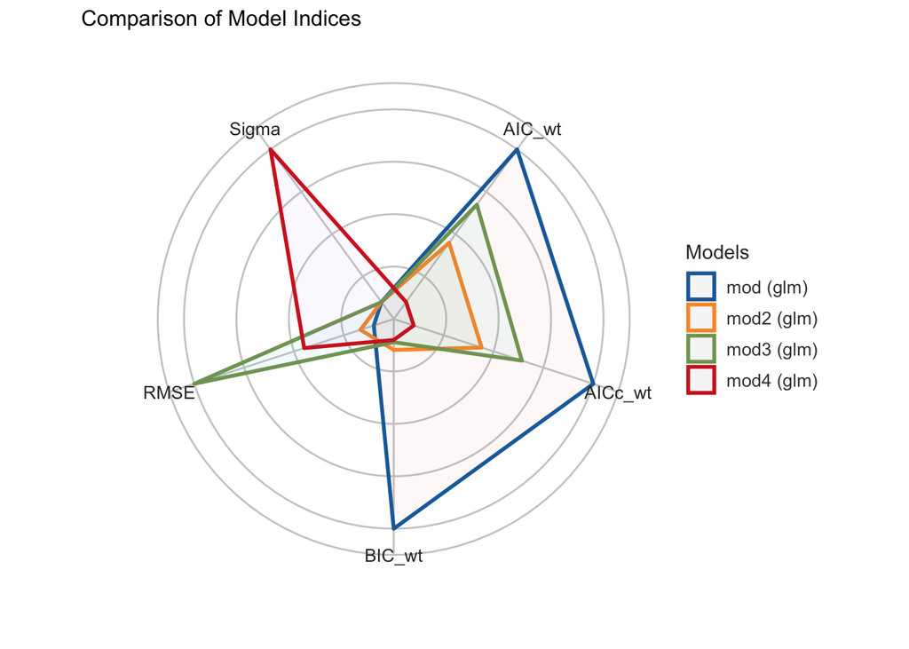

```r
compare_performance(mod, mod2, mod3, mod4) %>%
  plot()
```

We can see that mod works the best for most of the variables that we are looking for.

## Predictions

Predictions for the dataset.

```r
accuracy = dat %>%
  mutate(outcome = case_when(pred_1 < 0.2 ~ 'Not Admitted',
                             pred_1 >= 0.2 & pred_1 <= 0.4 ~ 'I dont know',
                             pred_1 > 0.4 ~ 'Admit')) %>%
  mutate(accurate = case_when(admit == 1 & outcome == 'Admit' ~ TRUE,
                              admit == 0 & outcome == 'Not Admitted' ~ TRUE,
                              TRUE ~ FALSE)) %>%
  pluck('accurate') %>%
  mean()


accuracy_2 <- dat %>%
  mutate(outcome_2 = case_when(pred_2 < 0.2 ~ 'Not Admitted',
                               pred_2 >= 0.2 & pred_2 <= 0.4 ~ 'I dont know',
                               pred_2 > 0.4 ~ 'Admit')) %>%
  mutate(accurate_2 = case_when(admit == 1 & outcome_2 == 'Admit' ~ TRUE,
                                admit == 0 & outcome_2 == 'Not Admitted' ~ TRUE,
                                TRUE ~ FALSE)) %>%
  pluck('accurate_2') %>%
  mean()
```

```r
accuracy
```

```
## [1] 0.3625
```

```r
accuracy_2
```

```
## [1] 0.355
```

## Model Choosing

This will allow us to create the best model:

```r
full_model = glm(data = dat,
                 formula = as.logical(admit) ~ gre*gpa*rank,
                 family = 'binomial')

stepwise_mod = stepAIC(full_model, direction = 'both')

best_model = glm(data = dat,
                 formula = stepwise_mod$formula,
                 family = 'binomial')

dat$pred_2 = predict(best_model, dat, type = 'response')
```

The predictions generated from pred_2 using the best model are more closely aligned with the actual admissions decisions compared to those from pred_1, indicating improved predictive performance.

```r
print(best_model$formula)
```

```
## as.logical(admit) ~ gre + gpa + rank + gre:gpa
```

Model comparisons:

```
## # Comparison of Model Performance Indices
##
## Name       | Model | AIC (weights) | AICc (weights) | BIC (weights) | Tjur's R2
## -------------------------------------------------------------------------------
## mod        |   glm | 467.4 (0.343) |  467.5 (0.349) | 483.4 (0.794) |     0.099
## mod2       |   glm | 469.3 (0.133) |  469.5 (0.132) | 489.3 (0.042) |     0.100
## best_model |   glm | 466.6 (0.524) |  466.7 (0.519) | 486.6 (0.165) |     0.105
##
## Name       |  RMSE | Sigma | Log_loss | Score_log | Score_spherical |   PCP
## ---------------------------------------------------------------------------
## mod        | 0.442 | 1.000 |    0.574 |   -50.496 |           0.004 | 0.609
## mod2       | 0.442 | 1.000 |    0.574 |   -50.609 |           0.004 | 0.610
## best_model | 0.440 | 1.000 |    0.571 |   -50.481 |           0.004 | 0.612
```

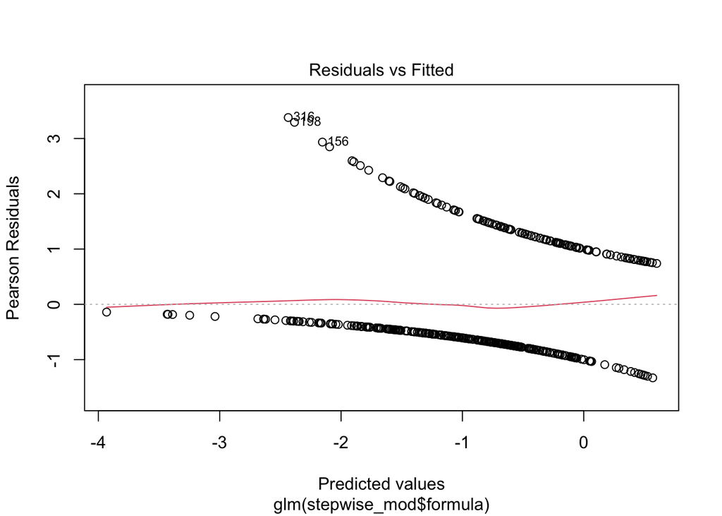

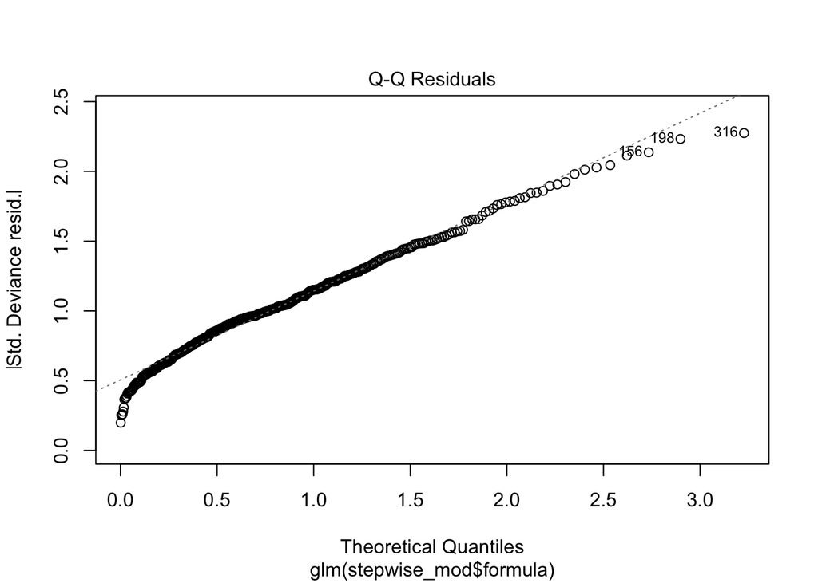

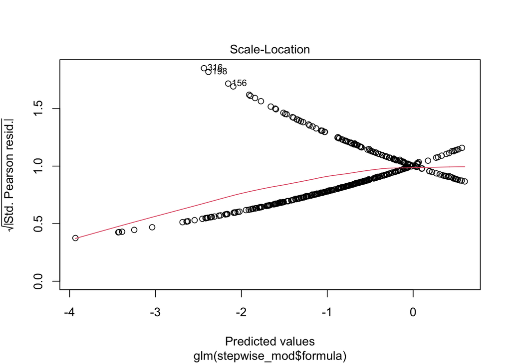

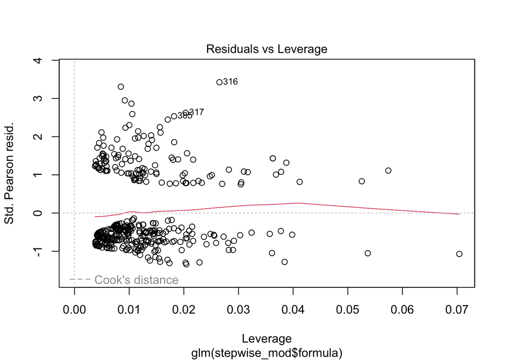

## Separating Data

```r
id = createDataPartition(dat$admit, p = 0.8, list = F)
dat_train = dat[id, ]
dim(dat_train)
dim(dat)

dat_test = dat[-id, ]

train_mod = glm(data = dat_train,
                formula = stepwise_mod$formula,
                family = 'binomial')

dat_test$pred = predict(train_mod, dat_test, type = 'response')
```

## Test Accuracy

```r
dat_test %>%
  mutate(pred_class = ifelse(pred > 0.5, 1, 0)) %>%
  summarise(test_accuracy = mean(pred_class == admit))
```

```
##   test_accuracy
## 1           0.6
```

## GPA vs. Predicted Probability of Admission

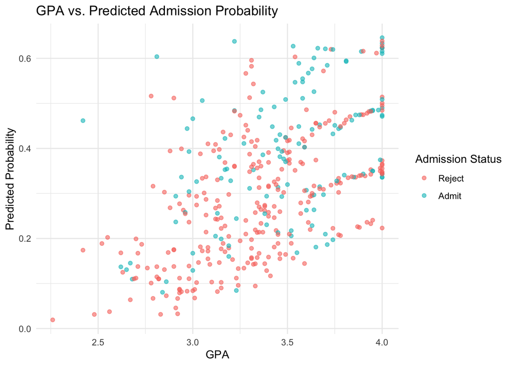

```r
dat %>%
  ggplot(aes(x = gpa, y = pred_2, color = factor(admit, labels = c("Reject", "Admit")))) +
  geom_point(alpha = 0.6) +
  labs(title = "GPA vs. Predicted Admission Probability",
       x = "GPA",
       y = "Predicted Probability",
       color = "Admission Status") +
  theme_minimal()
```

## GPA vs. GRE Scores for Admitted students

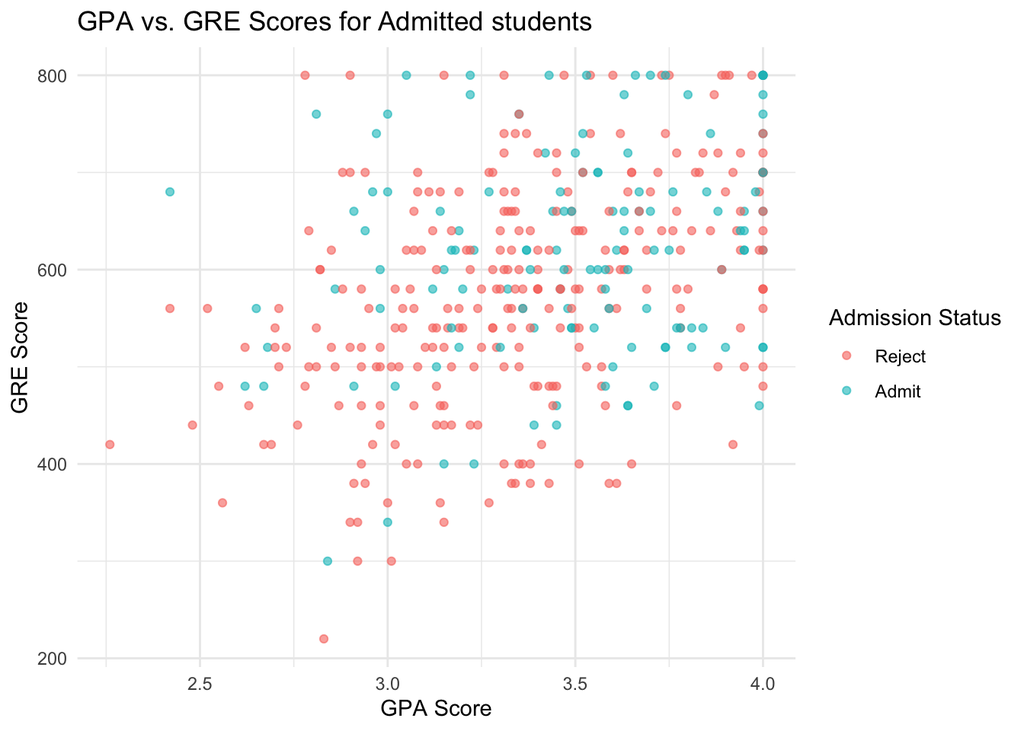

```r
dat %>%
  ggplot(aes(x = gpa, y = gre, color = factor(admit, labels = c("Reject", "Admit")))) +
  geom_point(alpha = 0.6) +
  labs(title = "GPA vs. GRE Scores for Admitted students",
       x = "GPA Score",
       y = "GRE Score",
       color = "Admission Status") +
  theme_minimal()
```

## GPA vs. Rank Scores for Admitted Students

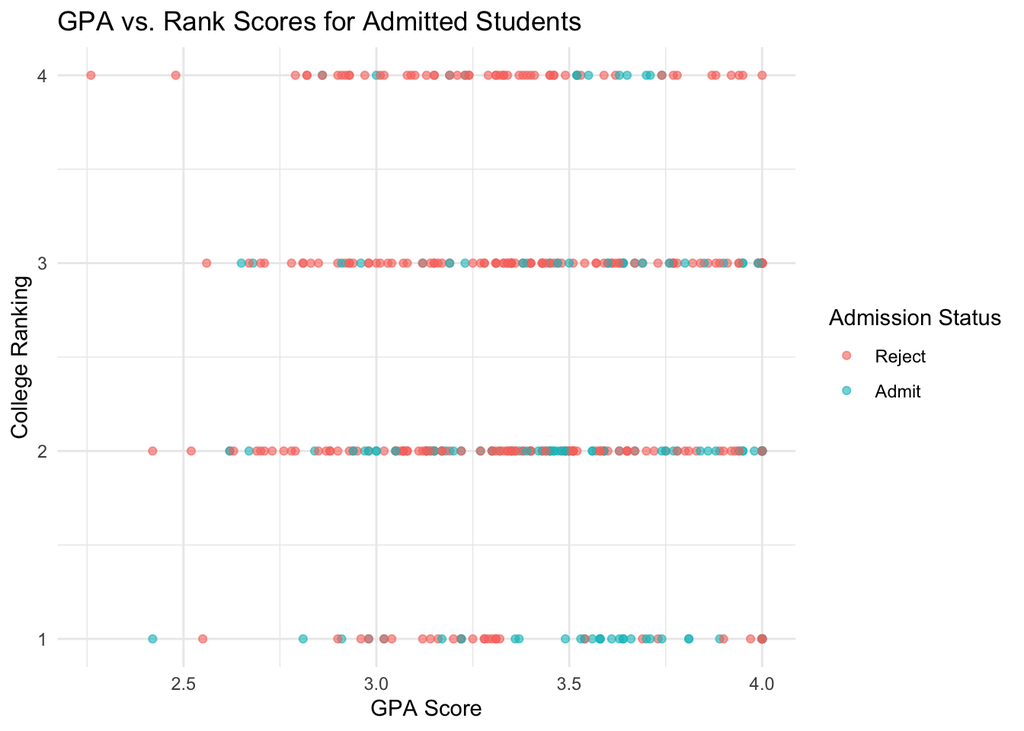

```r
dat %>%
  ggplot(aes(x = gpa, y = rank, color = factor(admit, labels = c("Reject", "Admit")))) +
  geom_point(alpha = 0.6) +
  labs(title = "GPA vs. Rank Scores for Admitted Students",
       x = "GPA Score",
       y = "College Ranking",
       color = "Admission Status") +
  theme_minimal()
```

## Conclusions

From the GPA vs. Predicted Admission Probability plot, we can observe a positive trend where higher GPA values generally correspond to higher probabilities of admission. Similarly, applicants with both high GRE and GPA scores had the highest chance of acceptance, as shown in the GPA vs. GRE plot.

Overall, this model could be useful for identifying strong applicants based on academic credentials, and for visualizing how different combinations of factors influence admission outcomes.